# HiFi Full-length 16S Analysis Report

## Summary QC statistics

- Samples number: 5
- Final samples number post-DADA2: 5
- Missing samples (Not enough reads, do not pass QC, etc):
- Total number of CCS reads before filtering and primers trimming: 180428
- Was primers trimmed prior to DADA2? Yes
- Total number of reads after quality filtering: 166853 (92.48%)
- Total number of reads after primers trimming (DADA2 input): 165185 (99%)
- Total number of ASVs found: 27
- Average number of ASVs per sample: 27
- Total number of reads in 27 ASVs: 123920 (75.02% of all input reads)

### Classification using VSEARCH with a single database

- ASVs classified at Species level: 27 (100%)
- ASVs classified at Species level (Excluding metagenome/uncultured entries): 27 (100%)
- Percentage reads belong to ASV classified at Species level (Excluding metagenome/uncultured entries): 100%
- ASVs classified at Genus level: 27 (100%)
- ASVs classified at Genus level (Excluding metagenome/uncultured entries): 27 (100%)
- Percentage reads belong to ASV classified at Genus level (Excluding metagenome/uncultured entries): 100%

### Classification using Naive Bayes classifier with SILVA, GTDB and RefSeq + RDP

- ASVs classified at Species level: 22 (81.48%)
- ASVs classified at Species level (Excluding metagenome/uncultured entries): 22 (81.48%)
- Percentage reads belong to ASV classified at Species level (Excluding metagenome/uncultured entries): 82%
- ASVs classified at Genus level: 24 (88.89%)
- ASVs classified at Genus level (Excluding metagenome/uncultured entries): 24 (88.89%)
- Percentage reads belong to ASV classified at Genus level (Excluding metagenome/uncultured entries): 93%

## Overall reads filtering and number of full-length reads

- Full-length reads are defined as reads with both F27 and R1492 primers
- Note that full length counts column will only show if cutadapt was used to trim primers (default).

|  | Sample | Reads before quality filter | Reads after quality filter | Full-length Reads | Full-length Reads Percent |
| --- | --- | --- | --- | --- | --- |
| 1 | 4112_bc1008--bc1075 | 39397 | 33604 | 33316 | 0.991429591715272 |
| 2 | 4128_bc1005--bc1107 | 25820 | 22282 | 21887 | 0.982272686473387 |
| 3 | 4170_bc1005--bc1096 | 38791 | 34633 | 34400 | 0.993272312534288 |
| 4 | 4285_bc1022--bc1107 | 21341 | 21322 | 21090 | 0.989119219585405 |
| 5 | 4296_bc1022--bc1060 | 55079 | 55012 | 54492 | 0.990547516905402 |

## Input reads QC (Before filtering and primers removal)

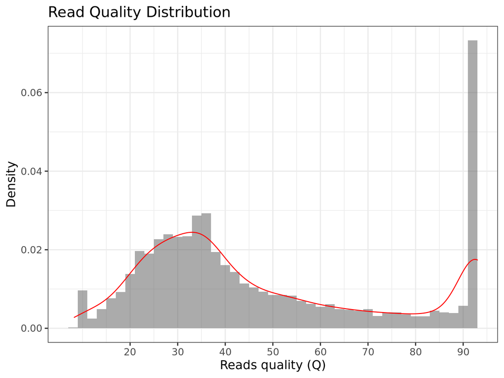

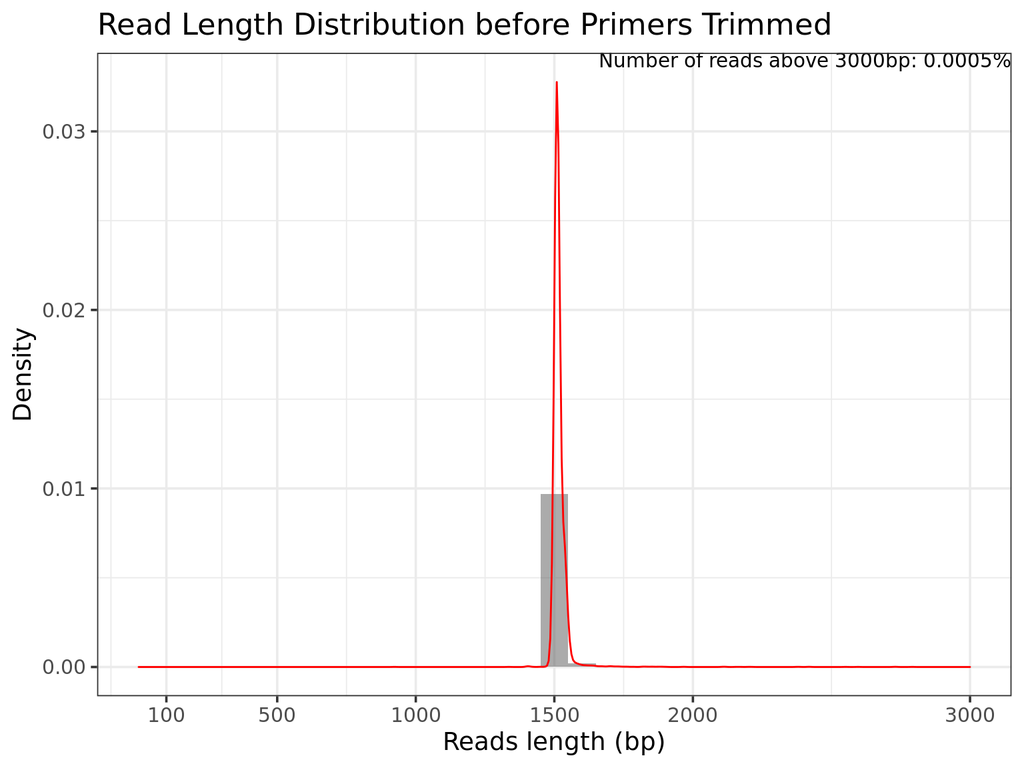

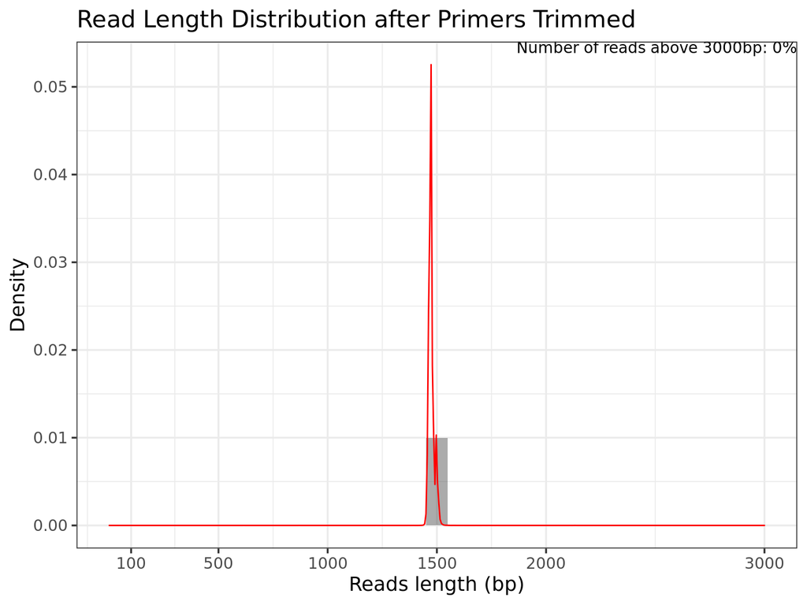

|  | Sample | Median Length (bp) | Median Read Quality | Length 1st Quartile (bp) | Length 3rd Quartile (bp) | Read Quality 1st Quartile (bp) | Read Quality 3rd Quartile (bp) |
| --- | --- | --- | --- | --- | --- | --- | --- |
| 1 | 4112_bc1008--bc1075 | 1512 | 36.42 | 1509 | 1522 | 25.37 | 58.66 |
| 2 | 4128_bc1005--bc1107 | 1512 | 33.1 | 1505 | 1522 | 24.59 | 47.45 |
| 3 | 4170_bc1005--bc1096 | 1512 | 40.71 | 1507 | 1521 | 28.67 | 73.77 |
| 4 | 4285_bc1022--bc1107 | 1511 | 49.5 | 1504 | 1514 | 34.21 | 90.04 |
| 5 | 4296_bc1022--bc1060 | 1511 | 37.59 | 1504 | 1519 | 29.25 | 62.95 |

## DADA2 QC metrics

|  | sample-id | input | filtered | percentage of input passed filter | denoised | non-chimeric | percentage of input non-chimeric | n_ASV |
| --- | --- | --- | --- | --- | --- | --- | --- | --- |
| 1 | 4112_bc1008--bc1075 | 33316 | 27023 | 81.11 | 26898 | 26890 | 80.71 | 27 |
| 2 | 4128_bc1005--bc1107 | 21887 | 16156 | 73.82 | 15004 | 14163 | 64.71 | 27 |
| 3 | 4170_bc1005--bc1096 | 34400 | 29109 | 84.62 | 28728 | 28654 | 83.3 | 27 |
| 4 | 4285_bc1022--bc1107 | 21090 | 18261 | 86.59 | 17923 | 17891 | 84.83 | 27 |
| 5 | 4296_bc1022--bc1060 | 54492 | 42356 | 77.73 | 39248 | 36322 | 66.66 | 27 |

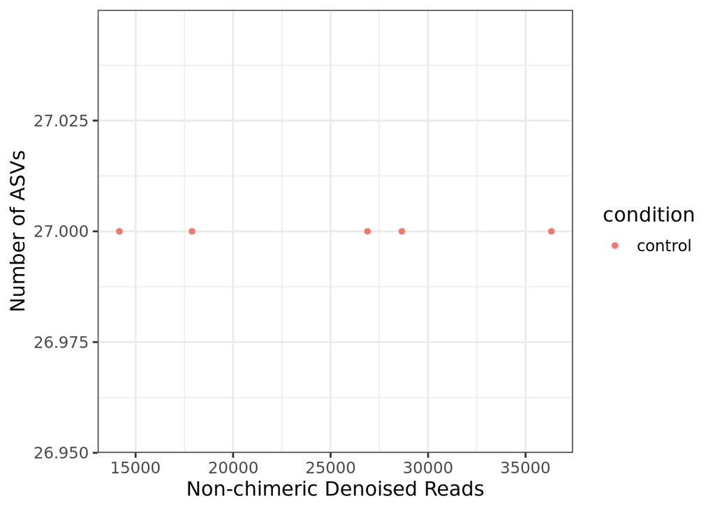

## Top Taxa and Plots

- For interactive view, use the Emperor QZV output from QIIME2 in `results/core-metrics-diversity` folder with QIIME2 View
- Note that if the distances between all samples are zero for a specific method, the plots will not be shown.
- MDS plots use ASVs as input.
- Samples might be missing due to choice of rarefecation depth. Rerun pipeline with `-resume --rarefaction_depth X` to choose a custom rarefecation depth X.

### Bray-Curtis MDS plot

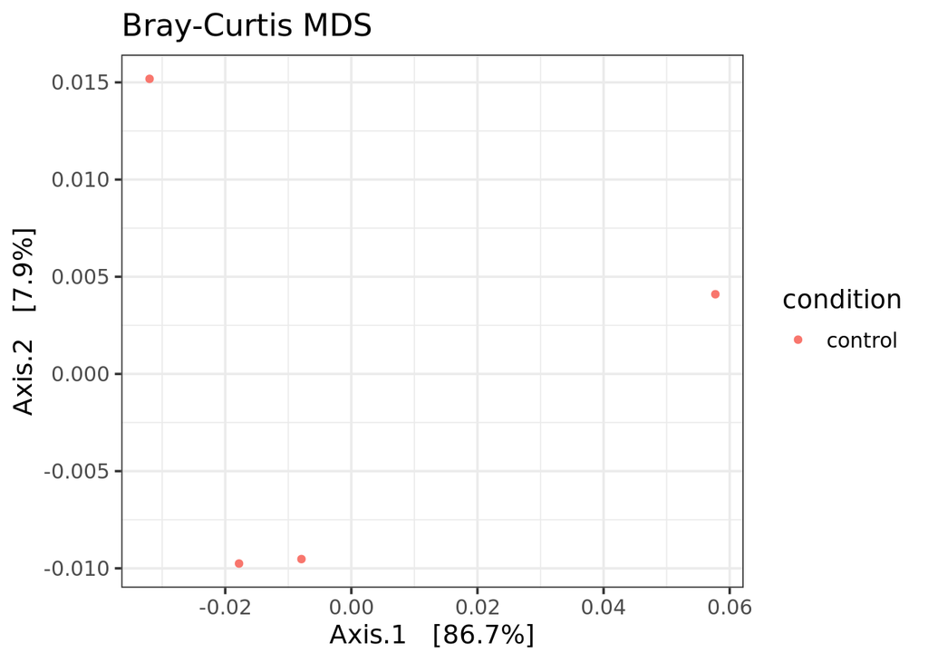

### Weighted and Unweighted Unifrac MDS plot

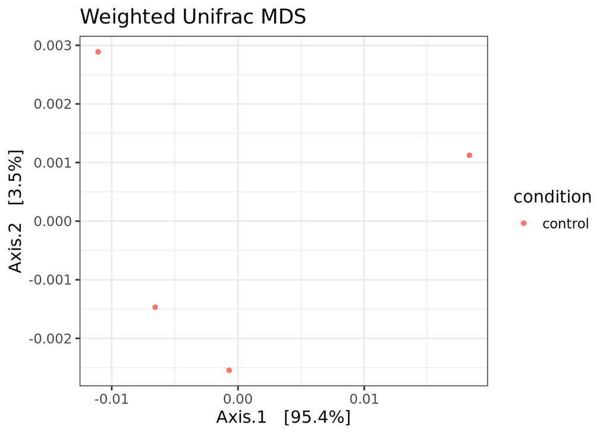

```
## [1] "All samples have distances of zero in unweighted Unifrac matrix"
```

### Top 50 ASVs (VSEARCH classification)

|  | OTU | Kingdom | Phylum | Class | Order | Family | Genus | Species | 4285_bc1022--bc1107 | 4128_bc1005--bc1107 | 4170_bc1005--bc1096 | 4112_bc1008--bc1075 | 4296_bc1022--bc1060 |
| --- | --- | --- | --- | --- | --- | --- | --- | --- | --- | --- | --- | --- | --- |
| 1 | e4326e04a50bad416b5aa32620852cbd | Bacteria | Firmicutes | Bacilli | Staphylococcales | Staphylococcaceae | Staphylococcus | Staphylococcus aureus | 2125 | 1815 | 3546 | 3504 | 4641 |
| 2 | 7149c9557908919f8c8890592dce06c8 | Bacteria | Proteobacteria | Gammaproteobacteria | Enterobacterales | Enterobacteriaceae | Salmonella | Salmonella enterica | 1682 | 1626 | 2770 | 2334 | 4126 |
| 3 | 6395873ddbb7d1a8e8dfe8652e482e70 | Bacteria | Firmicutes | Bacilli | Bacillales | Bacillaceae | Bacillus | Bacillus spizizenii | 1582 | 1244 | 2575 | 2345 | 3076 |
| 4 | 26cfdb2bcbd3a64a84e9b237d94a97eb | Bacteria | Firmicutes | Bacilli | Lactobacillales | Enterococcaceae | Enterococcus | Enterococcus faecalis | 1582 | 998 | 2568 | 2431 | 2566 |
| 5 | cbb8c7fab987004cb4135dca67812c6e | Bacteria | Firmicutes | Bacilli | Lactobacillales | Listeriaceae | Listeria | Listeria monocytogenes | 1246 | 907 | 2020 | 1898 | 2339 |
| 6 | a0ec2668157ffb2374ece8cad58ecc5f | Bacteria | Proteobacteria | Gammaproteobacteria | Pseudomonadales | Pseudomonadaceae | Pseudomonas | Pseudomonas aeruginosa | 994 | 655 | 1139 | 1338 | 2276 |
| 7 | 579aeb62d4fe9045ccbc28e8a6b199ae | Bacteria | Firmicutes | Bacilli | Bacillales | Bacillaceae | Bacillus | Bacillus spizizenii | 762 | 505 | 1238 | 1202 | 1307 |
| 8 | 752a3f85a4e352db4139ef9df88b9100 | Bacteria | Firmicutes | Bacilli | Lactobacillales | Listeriaceae | Listeria | Listeria monocytogenes B | 785 | 444 | 1258 | 1197 | 1196 |
| 9 | 3b44c0cd22f7eeac2386b9f2d475930a | Bacteria | Proteobacteria | Gammaproteobacteria | Enterobacterales | Enterobacteriaceae | Escherichia | Escherichia coli | 631 | 594 | 934 | 805 | 1568 |
| 10 | 685941421ec5ec3dd6a7649435daa0ad | Bacteria | Firmicutes | Bacilli | Staphylococcales | Staphylococcaceae | Staphylococcus | Staphylococcus aureus | 549 | 457 | 855 | 862 | 1029 |

[output cut: 17 more lines]

### Top 10 Classified Genus (Collapsed to species) with VSEARCH

- Relative abundance is calculated by dividing the number of reads for each ASV to the total number of reads in each sample.
- Heatmap contains only species with >1% abundance in at least 2 samples for the top 10 genus.

|  | Genus | Mean supporting reads across samples | Mean relative abundance across samples |
| --- | --- | --- | --- |
| 1 | Bacillus | 5022.2 | 0.2 |
| 2 | Staphylococcus | 4553.8 | 0.18 |
| 3 | Escherichia | 3115 | 0.13 |
| 4 | Listeria | 3173 | 0.13 |
| 5 | Salmonella | 2903.8 | 0.12 |
| 6 | Limosilactobacillus | 2706.8 | 0.11 |
| 7 | Enterococcus | 2029 | 0.08 |
| 8 | Pseudomonas | 1280.4 | 0.05 |

|  | Genus | Species | 4285_bc1022--bc1107 | 4128_bc1005--bc1107 | 4170_bc1005--bc1096 | 4112_bc1008--bc1075 | 4296_bc1022--bc1060 |
| --- | --- | --- | --- | --- | --- | --- | --- |
| 1 | Bacillus | Bacillus spizizenii | 3740 | 2722 | 6176 | 5708 | 6765 |
| 2 | Staphylococcus | Staphylococcus aureus | 3161 | 2630 | 5169 | 5189 | 6620 |
| 3 | Escherichia | Escherichia coli | 2184 | 2052 | 3370 | 2806 | 5163 |
| 4 | Listeria | Listeria monocytogenes | 1246 | 907 | 2020 | 1898 | 2339 |
| 5 | Listeria | Listeria monocytogenes B | 1200 | 723 | 1898 | 1808 | 1826 |
| 6 | Salmonella | Salmonella enterica | 1946 | 1897 | 3214 | 2729 | 4733 |
| 7 | Limosilactobacillus | Limosilactobacillus fermentum | 1838 | 1579 | 3100 | 2983 | 4034 |
| 8 | Enterococcus | Enterococcus faecalis | 1582 | 998 | 2568 | 2431 | 2566 |
| 9 | Pseudomonas | Pseudomonas aeruginosa | 994 | 655 | 1139 | 1338 | 2276 |

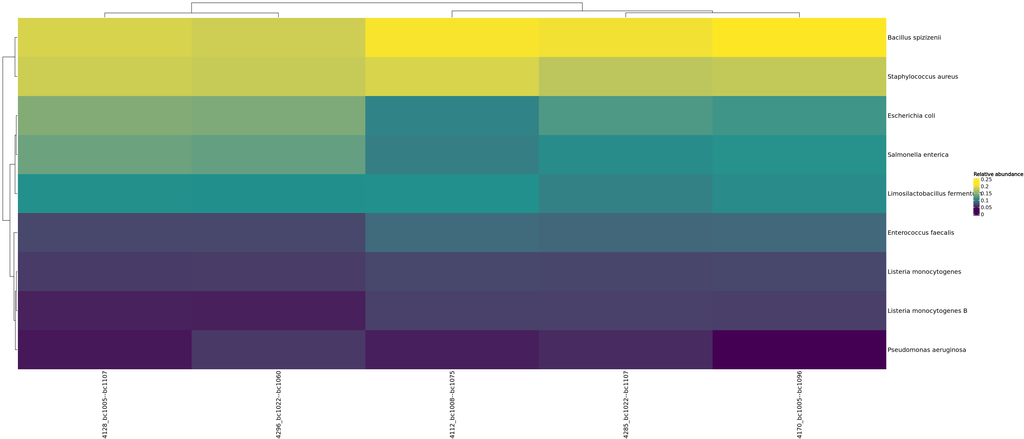

### Top 50 ASVs (Naive Bayes Classifier)

|  | OTU | Kingdom | Phylum | Class | Order | Family | Genus | Species | 4285_bc1022--bc1107 | 4128_bc1005--bc1107 | 4170_bc1005--bc1096 | 4112_bc1008--bc1075 | 4296_bc1022--bc1060 |
| --- | --- | --- | --- | --- | --- | --- | --- | --- | --- | --- | --- | --- | --- |
| 1 | e4326e04a50bad416b5aa32620852cbd | Bacteria | Firmicutes | Bacilli | Staphylococcales | Staphylococcaceae | Staphylococcus | Staphylococcus aureus | 2125 | 1815 | 3546 | 3504 | 4641 |
| 2 | 7149c9557908919f8c8890592dce06c8 | Bacteria | Proteobacteria | Gammaproteobacteria | Enterobacterales | Enterobacteriaceae | Salmonella | Salmonella enterica | 1682 | 1626 | 2770 | 2334 | 4126 |
| 3 | 6395873ddbb7d1a8e8dfe8652e482e70 | Bacteria | Firmicutes | Bacilli | Bacillales | Bacillaceae | Bacillus | Unclassified | 1582 | 1244 | 2575 | 2345 | 3076 |
| 4 | 26cfdb2bcbd3a64a84e9b237d94a97eb | Bacteria | Firmicutes | Bacilli | Lactobacillales | Enterococcaceae | Enterococcus | Enterococcus faecalis | 1582 | 998 | 2568 | 2431 | 2566 |
| 5 | cbb8c7fab987004cb4135dca67812c6e | Bacteria | Firmicutes | Bacilli | Lactobacillales | Listeriaceae | Listeria | Listeria monocytogenes | 1246 | 907 | 2020 | 1898 | 2339 |
| 6 | a0ec2668157ffb2374ece8cad58ecc5f | Bacteria | Proteobacteria | Gammaproteobacteria | Pseudomonadales | Pseudomonadaceae | Pseudomonas | Pseudomonas aeruginosa | 994 | 655 | 1139 | 1338 | 2276 |
| 7 | 579aeb62d4fe9045ccbc28e8a6b199ae | Bacteria | Firmicutes | Bacilli | Bacillales | Bacillaceae | Bacillus | Bacillus intestinalis | 762 | 505 | 1238 | 1202 | 1307 |
| 8 | 752a3f85a4e352db4139ef9df88b9100 | Bacteria | Firmicutes | Bacilli | Lactobacillales | Listeriaceae | Listeria | Listeria monocytogenes | 785 | 444 | 1258 | 1197 | 1196 |
| 9 | 3b44c0cd22f7eeac2386b9f2d475930a | Bacteria | Proteobacteria | Gammaproteobacteria | Unclassified | Unclassified | Unclassified | Unclassified | 631 | 594 | 934 | 805 | 1568 |
| 10 | 685941421ec5ec3dd6a7649435daa0ad | Bacteria | Firmicutes | Bacilli | Staphylococcales | Staphylococcaceae | Staphylococcus | Staphylococcus aureus | 549 | 457 | 855 | 862 | 1029 |

[output cut: 17 more lines]

### Top 10 Classified Genus (Collapsed to species) with Naive Bayes Classifier

- Relative abundance is calculated by dividing the number of reads for each ASV to the total number of reads in each sample.
- Heatmap contains only species with >1% abundance in at least 2 samples for the top 10 genus.

|  | Genus | Mean supporting reads across samples | Mean relative abundance across samples |
| --- | --- | --- | --- |
| 1 | Bacillus | 5022.2 | 0.2 |
| 2 | Staphylococcus | 4553.8 | 0.18 |
| 3 | Listeria | 3173 | 0.13 |
| 4 | Salmonella | 2903.8 | 0.12 |
| 5 | Limosilactobacillus | 2706.8 | 0.11 |
| 6 | Enterococcus | 2029 | 0.08 |
| 7 | Pseudomonas | 1280.4 | 0.05 |
| 8 | Collinsella | 449.4 | 0.02 |
| 9 | Escherichia | 433.2 | 0.02 |
| 10 | Escherichia-Shigella | 442.8 | 0.02 |

|  | Genus | Species | 4285_bc1022--bc1107 | 4128_bc1005--bc1107 | 4170_bc1005--bc1096 | 4112_bc1008--bc1075 | 4296_bc1022--bc1060 |
| --- | --- | --- | --- | --- | --- | --- | --- |
| 1 | Bacillus | Bacillus intestinalis | 2158 | 1478 | 3601 | 3363 | 3689 |
| 2 | Bacillus | Unclassified | 1582 | 1244 | 2575 | 2345 | 3076 |
| 3 | Staphylococcus | Staphylococcus aureus | 3161 | 2630 | 5169 | 5189 | 6620 |
| 4 | Listeria | Listeria monocytogenes | 2446 | 1630 | 3918 | 3706 | 4165 |
| 5 | Salmonella | Salmonella enterica | 1946 | 1897 | 3214 | 2729 | 4733 |
| 6 | Limosilactobacillus | Limosilactobacillus fermentum | 1838 | 1579 | 3100 | 2983 | 4034 |
| 7 | Enterococcus | Enterococcus faecalis | 1582 | 998 | 2568 | 2431 | 2566 |
| 8 | Pseudomonas | Pseudomonas aeruginosa | 994 | 655 | 1139 | 1338 | 2276 |
| 9 | Collinsella | Collinsella sp900764415 | 291 | 315 | 474 | 429 | 738 |
| 10 | Escherichia | Unclassified | 318 | 269 | 480 | 394 | 705 |

[output cut: 1 more lines]

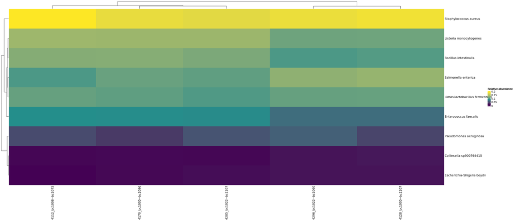